# MPG Prediction App

Peter Willmott

December 16, 2018

## What it does

Ever wondered what the MPG of a car is based on certain variables.. Probably not.. but regardless this app does it! This is a nice and simple app that uses a linear model to perdict the MPG of a car. The app uses the:

- Horsepower
- Number of Cylinders
- Weight

To provide a predicted MPG. You can slide and select to your hearts content and the app with update automatically providing you with the MPG.

The App - https://peter-willmott.shinyapps.io/car_spec_prediction/

The Repo - https://github.com/Peter-Willmott/MPG-Prediction

## The Data - Motor Trend Car Road Test

The app makes use of the ‘mtcars’ dataset.

### Description

The data was extracted from the 1974 Motor Trend US magazine, and comprises fuel consumption and 10 aspects of automobile design and performance for 32 automobiles (1973–74 models).

### Source

Henderson and Velleman (1981), Building multiple regression models interactively. Biometrics, 37, 391–411.

### Used

- MPG - Miles/(US) gallon
- HP - Gross Horsepower
- Cyl - Number of Cylinders
- Wt - Weight (1000lbs)

## Variables

```r
require(car)
cars_sub <- subset(mtcars, select = c(mpg, hp, cyl, wt))
summary(cars_sub)
```

```
##       mpg              hp             cyl              wt
##  Min.   :10.40   Min.   : 52.0   Min.   :4.000   Min.   :1.513
##  1st Qu.:15.43   1st Qu.: 96.5   1st Qu.:4.000   1st Qu.:2.581
##  Median :19.20   Median :123.0   Median :6.000   Median :3.325
##  Mean   :20.09   Mean   :146.7   Mean   :6.188   Mean   :3.217
##  3rd Qu.:22.80   3rd Qu.:180.0   3rd Qu.:8.000   3rd Qu.:3.610
##  Max.   :33.90   Max.   :335.0   Max.   :8.000   Max.   :5.424
```

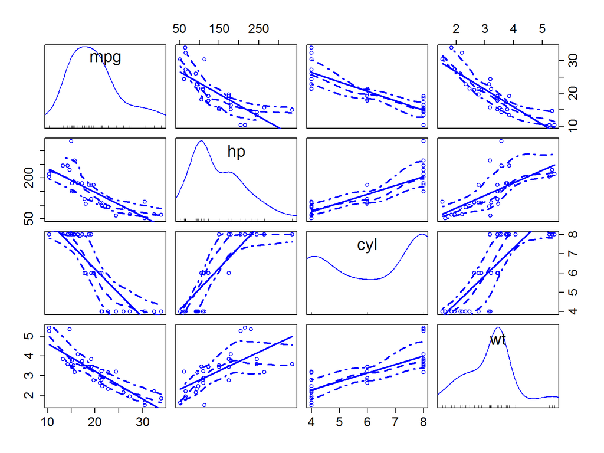

```r
scatterplotMatrix(~mpg+hp+cyl+wt, data=cars_sub, cex.axis=1.5)
```

## Nitty Gritty

The application displays the user input controls on the left. These provide sliders and radio buttons to select the required values. These values are displayed on the right and updated as they are changed by the user

The right panel shows the output, as stated above it displays the user input values currently selected but it also shows the MPG prediction. This can be seen at the bottom (the final output box). This value gives you a quick prediction of the MPG you could expexct from a car with the selected specs. The simple computation allows the calculation to be done on the fly!

I hope you enjoyed this simple app and have a nice day!!